# En Passant: An Analysis of Trends and Patterns in Chess

Chess is one of the most popular board games. It is played on many levels: here in the Philippines, we can commonly see people playing Chess with each other on the street, yet international tournaments are held as well and Chess champions and grandmasters enjoy relatively widespread fame.

Chessgames.com is an internet site dedicated to Chess. On the chessgames site we can find game, tournament, and player data among other things such as Chess openings and the like.

## Problem

How has the Chess tournament scene been affected by time? Has it been decreasing? Increasing? Are there dips or peaks?

Do Chess players move randomly or are there similarities or patterns in how Chess players play? If there are patterns, how can we interpret them and which patterns are the most successful? Knowing these will allow Chess players (aspiring Chess champions) to know which patterns to practice and emulate.

## Table of Contents

### Section 1. Executive Summary

### Section 2. Preliminaries

### Section 3. EDA

### Section 4. Story

### Section 5. Conclusion and Closing

## Section 1. Executive Summary

For chess games enthusiasts, it is their desire to become good chess players and to be ranked among the best in this tournament. What better way to improve their skills by learning from the world’s best? This report will provide information on proven winning strategy played in this game by the best chess players around the world. This information should help aspiring players to hone their skills and to show that they have what it takes to become champions in the game of chess.

Chess games information were retrieved from the website, Chessgames.com. It has an online database which contains records of chess games played around the world since 1843 and information about world known chess game players. It is also a community with a discussion forum where members can discuss anything about chess. Web scraping using Python’s library BeautifulSoup was used to gather data from the website.

Player information was also retrieved which includes their FIDE-rating and the number of game played. FIDE which stands for Fédération Internationale Des Échecs is the governing body for international chess competitions. This information showed that there is a correlation with the number of games played with the higher FIDE-rating. Chess game enthusiasts should become followers of and should learn from players with higher FIDE-rating.

The opening moves taken by the players from about 900,000+ chess games were also analyzed. From 20 possible first moves, the move that is most taken by the white player is the pawn moving to E4. This was the first move in 47% of all the games. Further, 38% of the games with this first move were won. The heat maps of the most common first move by both White player and the success of the corresponding game are shown on the report. These are guides to chess players on how to start a game with a high level of probability of winning the game.

Lastly, the discussion forum was reviewed with the objective of learning what are the topics of interest discussed by the members of the site. This information can help interested individuals in using the right keywords to search the forum for tips and techniques that can help them in their journey to become better chess players.

## Section 2. Preliminaries

### Importing Libraries and Defining Functions

*This code imports all the libraries/modules that will be used for this notebook.*

```python
# Libraries for data processing and storage
import pandas as pd
import numpy as np
import sqlite3

# Libraries for plotting and visualization
import matplotlib.pyplot as plt
%matplotlib inline
plt.rcParams['font.family'] = 'serif'
import seaborn as sns
sns.set_context("talk")



# Libraries for web scraping
import requests
from bs4 import BeautifulSoup
from time import sleep

# Counter
from collections import Counter

# For displaying HTML and Images
from IPython.display import HTML
from IPython.display import Image as PImage
from PIL import Image

# Ignore warnings
import warnings
warnings.filterwarnings('ignore')

# Libraries for string/text processing
import re
import string
from nltk.corpus import stopwords
import nltk
nltk.download('stopwords')
from wordcloud import WordCloud, STOPWORDS

# Library for fitting
from lmfit import Model

# Utilities
import os
```

```python
import sys
sys.path.append('../enpassant')

from enpassant.config import csv_data_path
from enpassant.config import db_data_path

from enpassant.functions import sorter
```

#### Retrieving the Scraped Data from the SQLite Database

We retrieve the contents of our SQLite database `tournaments_1843_to_2019.db`

```python
conn = sqlite3.connect(db_data_path)
c = conn.cursor()

# Retrieve tournament games
df_tourn_games = pd.DataFrame(c.execute(
    """
SELECT * FROM games
""").fetchall(),
    columns=['event_locale', 'game', 'moves', 'opening', 'result', 'year'])
df_tourn_games = df_tourn_games.drop_duplicates()
df_tourn_games['year'] = df_tourn_games['year'].astype('int64')
df_tourn_games['moves'] = df_tourn_games['moves'].astype('int64')

# Retrieve player data
df_players = pd.DataFrame(c.execute(
    """
SELECT * FROM players
""").fetchall(), columns=['fide', 'name', 'games', 'start_year', 'end_year'])
# df_players['fide'] = df_players['fide'].astype('int64')
df_players['start_year'] = df_players['start_year'].astype('int64')
df_players['end_year'] = df_players['end_year'].astype('int64')

# Retrieve opening squares
df_explorer = pd.DataFrame(c.execute(
    """
SELECT * FROM first_move
""").fetchall())
df_explorer.columns = ['move', 'games', 'order', 'white', 'black', 'draw']

# Retrieve chessforums forums
df_texts = pd.DataFrame(c.execute(
    """
SELECT * FROM texts
""").fetchall())
df_texts.columns = ['name', 'text']

# Retrieve ECO opening codes
df_eco = pd.DataFrame(c.execute(
    """
SELECT * FROM eco_codes
""").fetchall())
df_eco.columns = ['eco_code', 'title']
df_eco = df_eco.set_index('eco_code')['title']
```

## Section 3. EDA

Let's take a look at the data we scraped:

### Tournament Games from years 1843 to 2019

Heading the data of all the tournament games from 1843 to 2019:

*In this cell we make a DataFrame `df1` simply to make it easier to type, and we manipulate the `opening` column as well.*

```python
# Shorten df_tourn_games to df1 to make it easier to type:
df1 = df_tourn_games.copy()

# Separating the 'opening' into its name and its code:
df1['opening'] = df1['opening'].str.split(n=1)
df1['opening_code'] = df1['opening'].apply(lambda x: x[0])
df1['opening'] = df1['opening'].apply(lambda x: x[1])
df1['opening'] = df1['opening'].str.split(',', n=1)
df1['opening'] = df1['opening'].apply(lambda x: x[0])

display(HTML('Head of the data:'))
display(df1.head())

display(HTML('Tail of the data:'))
display(df1.tail())
```

Head of the data:

|  | event_locale | game | moves | opening | result | year | opening_code |
| --- | --- | --- | --- | --- | --- | --- | --- |
| 0 | Staunton - Saint Amant | 1. Saint Amant vs Staunton | 69 | Sicilian | 0-1 | 1843 | B20 |
| 1 | Staunton - Saint Amant | 2. Staunton vs Saint Amant | 89 | Bishop's Opening | ½-½ | 1843 | C24 |
| 2 | Staunton - Saint Amant | 3. Saint Amant vs Staunton | 35 | Giuoco Piano | 1-0 | 1843 | C53 |
| 3 | Staunton - Saint Amant | 4. Staunton vs Saint Amant | 30 | Giuoco Piano | 1-0 | 1843 | C53 |
| 4 | Staunton - Saint Amant | 5. Saint Amant vs Staunton | 60 | Sicilian | 1-0 | 1843 | B40 |

Tail of the data:

|  | event_locale | game | moves | opening | result | year | opening_code |
| --- | --- | --- | --- | --- | --- | --- | --- |
| 244001 | FIDE Grand Prix Moscow | 42. R Wojtaszek vs I Nepomniachtchi | 40 | King's Indian | ½-½ | 2019 | A48 |
| 244002 | FIDE Grand Prix Moscow | 43. Grischuk vs I Nepomniachtchi | 38 | Grunfeld | ½-½ | 2019 | D85 |
| 244003 | FIDE Grand Prix Moscow | 44. I Nepomniachtchi vs Grischuk | 23 | Ruy Lopez | ½-½ | 2019 | C67 |
| 244004 | FIDE Grand Prix Moscow | 45. Grischuk vs I Nepomniachtchi | 37 | Petrov Defense | ½-½ | 2019 | C42 |
| 244005 | FIDE Grand Prix Moscow | 46. I Nepomniachtchi vs Grischuk | 36 | Giuoco Piano | 1-0 | 2019 | C53 |

We have 7 columns:

- `event_locale` - the tournament name or the location of the game
- `game` - game number in the tournament and the two players, White vs. Black
- `moves` - number of moves in the game; note that one move consists of white's move and black's move
- `opening` - name of the opening move set
- `result`
  - White Win [1-0]
  - Black Win [0-1]
  - Draw [1/2-1/2]
- `year`
- `opening_code` - a code designating which opening move set was used, according to the Encyclopedia of Chess Openings (ECO)

Let's describe the numerical data:

```python
df1.describe()
```

|  | moves | year |
| --- | --- | --- |
| count | 243856.000000 | 243856.000000 |
| mean | 43.680205 | 2000.213864 |
| std | 17.172819 | 31.599698 |
| min | 0.000000 | 1843.000000 |
| 25% | 32.000000 | 2006.000000 |
| 50% | 41.000000 | 2014.000000 |
| 75% | 53.000000 | 2017.000000 |
| max | 228.000000 | 2019.000000 |

### Games

Let's try to take a quick look at the number of games per year:

*This cell plots the probability density of games per year.*

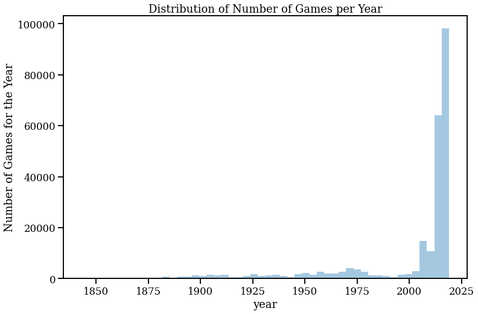

```python
fig, ax = plt.subplots(1, 1, figsize=(12, 8))
ax = sns.distplot(df1['year'], kde=False)
ax.set_ylabel('Number of Games for the Year')
ax.set_title('Distribution of Number of Games per Year')
plt.show()
```

The number of games ballooned up recently, making it hard to see the distribution of games for previous years, so let's try to make the y-axis logarithmic.

*This cell plots the probability density of the games per year, but with the y-axis in logarithmic scale to mitigate the effects of the recent ballooning.*

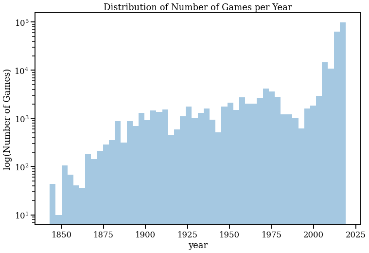

```python
fig, ax = plt.subplots(1, 1, figsize=(12, 8))
ax = sns.distplot(df1['year'], kde=False)
ax.set_title('Distribution of Number of Games per Year')
ax.set_ylabel('log(Number of Games)')
ax.set_yscale('log')
plt.show()
```

There is a general upward trend, but we see some time periods where there are dips in the number of games. More on that later.

### Moves

Summary of the number of moves per game:

```python
print(df1['moves'].describe(), '\n')
```

```
count    243856.000000
mean         43.680205
std          17.172819
min           0.000000
25%          32.000000
50%          41.000000
75%          53.000000
max         228.000000
Name: moves, dtype: float64
```

#### ANALYSIS

We notice that the mean and median are quite close to each other. Is the distribution approximately normal? It seems to be so, but we notice that the maximum is 228! Perhaps it is slightly skewed to the right? Let's take a better look using a box plot and a histogram.

*In this cell we draw (1) a box plot, and (2), a probability density of the number of games vs. the number of moves in a game.*

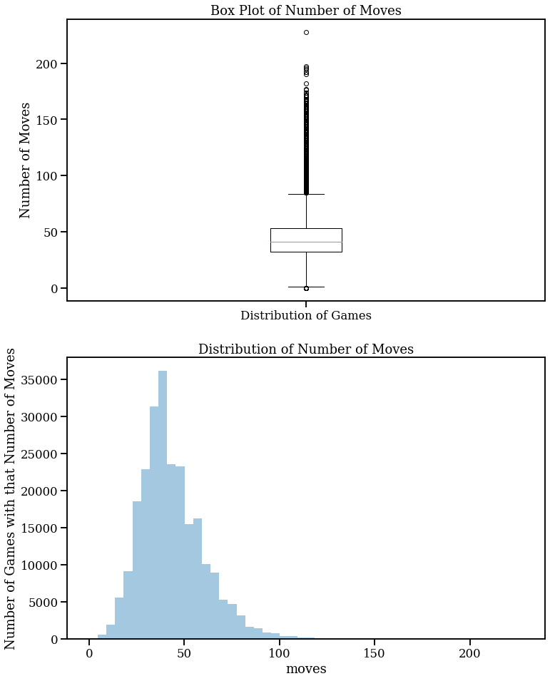

```python
fig, ax = plt.subplots(2, 1, figsize=(12, 16))
ax[0].boxplot(df1['moves'])
ax[0].set_title('Box Plot of Number of Moves')
ax[0].set_xticklabels(['Distribution of Games'])
ax[0].set_ylabel('Number of Moves')
ax[1] = sns.distplot(df1['moves'], kde=False)
ax[1].set_title('Distribution of Number of Moves')
ax[1].set_ylabel('Number of Games with that Number of Moves')
plt.show()
```

#### ANALYSIS

As suspected, the distribution is slightly skewed to the right. However, this is likely because of the existence of a lower limit at zero (of course, there can never be a negative number of moves!).

Let's take a look at the games at both ends of the extreme.

```python
display(HTML('Games with only one move:'))
display(df1.loc[df1['moves'] == 1])
display(HTML('Game with the most number of moves:'))
display(df1.loc[df1['moves'] >= 228])
```

Games with only one move:

|  | event_locale | game | moves | opening | result | year | opening_code |
| --- | --- | --- | --- | --- | --- | --- | --- |
| 4205 | Hastings | 182. Pillsbury vs Von Bardeleben | 1 | Queen's Pawn Game | 1-0 | 1895 | A40 |
| 35821 | Palma de Mallorca Interzonal | 276. Fischer vs Panno | 1 | English | 1-0 | 1970 | A10 |
| 38874 | USSR Championship | 33. K Grigorian vs Savon | 1 | Uncommon Opening | 1-0 | 1973 | A00 |
| 40479 | Teesside | 103. Huebner vs Miles | 1 | Uncommon Opening | 0-1 | 1975 | A00 |
| 40837 | Manila Interzonal | 151. Ribli vs Quinteros | 1 | Reti Opening | 1-0 | 1976 | A04 |
| 43934 | Lone Pine | 20. Janosevic vs A T Arnason | 1 | Uncommon King's Pawn Opening | 1-0 | 1978 | B00 |
| 44393 | Buenos Aires (Clarin) | 91. Dzindzichashvili vs Qi Jingxuan | 1 | English | 1-0 | 1978 | A10 |
| 47671 | Szirak | 56. Sax vs Adorjan | 1 | Uncommon King's Pawn Opening | ½-½ | 1985 | B00 |
| 53153 | Corus Reserve Group | 187. M Etmans vs E Oosterom | 1 | Uncommon King's Pawn Opening | ½-½ | 2001 | B00 |
| 70317 | World Open | 172. Shabalov vs Ehlvest | 1 | King's Pawn Game | ½-½ | 2008 | C20 |
| 92580 | 67th Moscow Blitz Championship | 76. Karjakin vs Grischuk | 1 | Uncommon Opening | ½-½ | 2013 | A00 |
| 93422 | World Junior Championship (Girls) | 11. P Rodriguez Rueda vs L Armas | 1 | Uncommon Opening | 1-0 | 2013 | A00 |
| 101814 | Rilton Cup 2013/14 | 19. Smirin vs D Arman | 1 | Uncommon King's Pawn Opening | 1-0 | 2013 | B00 |
| 101815 | Rilton Cup 2013/14 | 20. S Volkov vs T Glimbrant | 1 | Queen's Pawn Game | 1-0 | 2013 | A40 |
| 113427 | British Championship | 212. R Pert vs N Pert | 1 | King's Pawn Game | ½-½ | 2014 | C20 |
| 119357 | European Club Cup | 308. F Bindrich vs S Zhigalko | 1 | Uncommon Opening | ½-½ | 2014 | A00 |
| 127212 | Bunratty Classic | 19. B Thorfinnsson vs S Williams | 1 | Uncommon Opening | ½-½ | 2015 | A00 |
| 131069 | Dubai Chess Open | 38. R Kulkarni vs A Shimanov | 1 | Uncommon King's Pawn Opening | 1-0 | 2015 | B00 |
| 140031 | Millionaire Chess | 44. Yu Yangyi vs T Luukkonen | 1 | Uncommon King's Pawn Opening | 1-0 | 2015 | B00 |
| 140068 | Millionaire Chess | 81. A Jakubiec vs Kamsky | 1 | Reti Opening | 1-0 | 2015 | A04 |
| 159153 | Chess Olympiad | 1344. Kutesa Willy Mimbasa vs Adrian Woodley | 1 | King's Pawn Game | 0-1 | 2016 | C20 |
| 198455 | World Senior 50+ | 7. K Vebic vs Khalifman | 1 | Uncommon King's Pawn Opening | 1-0 | 2017 | B00 |
| 200628 | European Blitz Championship | 84. A Maly vs Krzysztof Kolodziej | 1 | Sicilian | 1-0 | 2017 | B20 |
| 200662 | European Blitz Championship | 118. L Trent vs Hubert Janzer | 1 | King's Pawn Game | 1-0 | 2017 | C20 |
| 200698 | European Blitz Championship | 154. J Gdanski vs Valdis Visnevskis | 1 | Uncommon Opening | 1-0 | 2017 | A00 |
| 201629 | European Blitz Championship | 1085. Dmitry Nestorenko vs Pribyl | 1 | King's Pawn Game | 0-1 | 2017 | C20 |
| 214572 | European Individual Chess Championship | 101. Aydin Suleymanli vs Semyon Lomasov | 1 | Queen's Pawn Game | ½-½ | 2018 | A40 |
| 219320 | American Continental | 839. S Foisor vs E Moradiabadi | 1 | Reti Opening | ½-½ | 2018 | A04 |
| 222700 | Chess Olympiad | 331. Elmer Prudente vs N A Hussein | 1 | Alekhine's Defense | 0-1 | 2018 | B02 |
| 233224 | World Rapid Championship | 1495. Vitaly Gurvich vs D Gordievsky | 1 | English | ½-½ | 2018 | A10 |

Game with the most number of moves:

|  | event_locale | game | moves | opening | result | year | opening_code |
| --- | --- | --- | --- | --- | --- | --- | --- |
| 84359 | 13th European Individual Championship | 1488. V Sanal vs E Can | 228 | Sicilian | ½-½ | 2012 | B32 |

Why do some games end after only one move by white? Let's try to look at the outcomes:

```python
df1.loc[df1['moves'] == 1].groupby('result')['game'].count()
```

```
result
0-1     4
1-0    16
½-½    10
Name: game, dtype: int64
```

#### ANALYSIS

In these games with only one move, most of the time white wins because black forfeits as soon as white makes their move. However 10 of the games ended with a draw, and 4 games ended with a black win.

Reading some of the kibitzing on the one-move games, We discovered that forfeits were often done for players to conserve energy.

### Openings

Let's take a look at the number of games by opening.

*This cell groups the counts of the games by the `opening_code` column.*

```python
df1_opening_codes = df1.groupby('opening_code')['game'].count().drop('000')
```

Now we will plot the Top 10 openings in a bar chart:

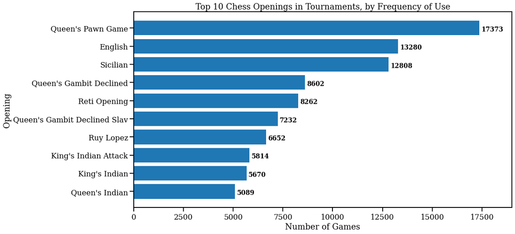

```python
# Calling sorter() so that the order will be consistent:
opening_codes = sorter(df1_opening_codes.index, df1_opening_codes)

# Creating a small dataframe to hold retrieved entries
df1_openings = df1_opening_codes.copy()
df1_openings.index = list(map(lambda x: df_eco[x], df1_openings.index))

# Merging duplicate names
df1_openings = df1_openings.groupby(level=0).sum()
fig, ax = plt.subplots(1, 1, figsize=(15, 8))
openings = sorter(df1_openings.index, df1_openings)
widths = openings[1][-10:]
ax.barh(openings[0][-10:], widths)
ax.set_xlim(0, 19000)
ax.set_title('Top 10 Chess Openings in Tournaments, by Frequency of Use')
ax.set_xlabel('Number of Games')
ax.set_ylabel('Opening')
for i, v in enumerate(widths):
    ax.text(v+100, i-0.17, str(v), color='k', fontweight='bold', fontsize=14)
```

Now, we will separate the opening moves by winning side (white or black) to see whether there is a change.

*The following cell creates a DataFrame that includes the winning percentage by side for each opening.*

```python
df1_openings_wins = df1.groupby(
    ['opening_code', 'result']).size().unstack().drop(index='000')
df1_openings_wins.index = list(
    map(lambda x: df_eco[x], df1_openings_wins.index))

# Merging duplicate names
df1_openings_wins = df1_openings_wins.groupby(level=0).sum()

# Converting wins to winning proportions
opening_totals = list(df1_openings_wins.apply(lambda x: x.sum(), axis=1))
df1_openings_wins = df1_openings_wins.apply(lambda x: x/x.sum(), axis=1)
df1_openings_wins['total'] = opening_totals
df1_openings_wins.head()
```

| result | 0-1 | 1-0 | ½-½ | total |
| --- | --- | --- | --- | --- |
| Alekhine's Defense | 0.359288 | 0.371524 | 0.269188 | 899.0 |
| Alekhine's Defense, Modern | 0.270627 | 0.445545 | 0.283828 | 606.0 |
| Benko Gambit | 0.303944 | 0.430008 | 0.266048 | 1293.0 |
| Benoni | 0.305556 | 0.458333 | 0.236111 | 144.0 |
| Benoni Defense | 0.334200 | 0.405722 | 0.260078 | 769.0 |

Some strategies are better for different sides. For example, the Modern Alexhine's Defense is seen more often in a white victory.

### First Moves

Here we are able to see the square that White first makes its move onto, in order of frequency of use, under `games` column.

```python
df_explorer.head()
```

|  | move | games | order | white | black | draw |
| --- | --- | --- | --- | --- | --- | --- |
| 0 | e4 | 428372.0 | 1 | 37.9 | 30.0 | 32.1 |
| 1 | d4 | 317886.0 | 1 | 37.7 | 26.6 | 35.7 |
| 2 | Nf3 | 82482.0 | 1 | 37.1 | 24.9 | 38.0 |
| 3 | c4 | 64497.0 | 1 | 38.1 | 25.3 | 36.6 |
| 4 | g3 | 5617.0 | 1 | 38.4 | 27.4 | 34.2 |

### Players

List of the chess players, their names, number of games played, and start and end years.

```python
df2 = df_players.copy()
```

```python
df2.head()
```

|  | fide | name | games | start_year | end_year |
| --- | --- | --- | --- | --- | --- |
| 0 | 2400.0 | AABERG, Anton | 55 | 1991 | 2012 |
| 1 | 2403.0 | AABLING-THOMSEN, Jakob | 129 | 2000 | 2018 |
| 2 | 2542.0 | AAGAARD, Jacob | 208 | 1991 | 2017 |
| 3 | 2334.0 | AAKANKSHA, Hagawane | 35 | 2014 | 2017 |
| 4 | 2362.0 | AARON, Deepak | 31 | 2008 | 2017 |

```python
df2.describe()
```

|  | fide | games | start_year | end_year |
| --- | --- | --- | --- | --- |
| count | 8566.000000 | 9814.000000 | 9814.000000 | 9814.000000 |
| mean | 2361.446299 | 150.415019 | 1985.065417 | 2005.615753 |
| std | 184.150082 | 283.432408 | 30.024444 | 24.920336 |
| min | 1379.000000 | 26.000000 | 1497.000000 | 1625.000000 |
| 25% | 2269.000000 | 38.000000 | 1977.000000 | 2007.000000 |
| 50% | 2389.000000 | 60.000000 | 1994.000000 | 2016.000000 |
| 75% | 2479.000000 | 132.000000 | 2004.000000 | 2018.000000 |
| max | 2882.000000 | 4418.000000 | 2018.000000 | 2019.000000 |

#### Highest FIDE Ratings

*This cell shows (1) a boxplot, and (2) a probability density of the distribution of players by highest FIDE rating achieved.*

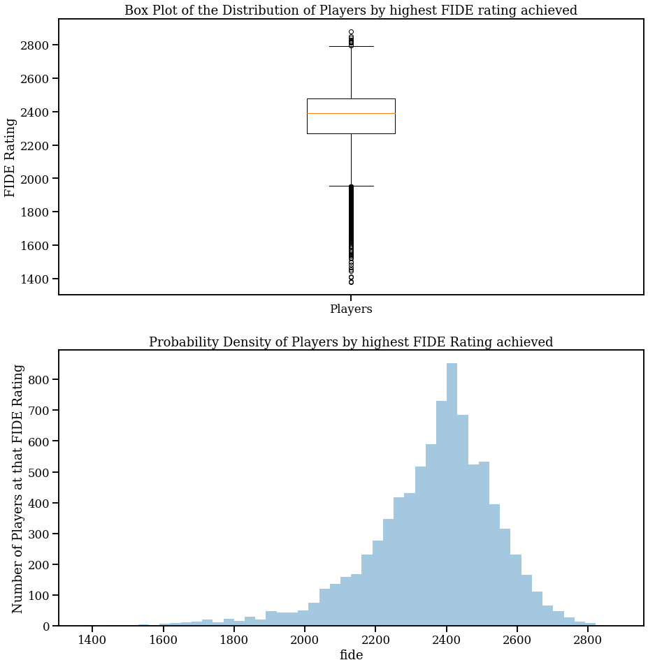

```python
fig, ax = plt.subplots(2, 1, figsize=(15, 16))
ax[0].boxplot(df2['fide'].dropna())
ax[0].set_title(
    'Box Plot of the Distribution of Players by highest FIDE rating achieved')
ax[0].set_xticklabels(['Players'])
ax[0].set_ylabel('FIDE Rating')
ax[1] = sns.distplot(df2['fide'].dropna(), kde=False)
ax[1].set_title(
    'Probability Density of Players by highest FIDE Rating achieved')
ax[1].set_ylabel('Number of Players at that FIDE Rating')
plt.show()
```

#### Games Played

*This cell shows (1) a boxplot, and (2) a probability density of the distribution of players by number of games played.*

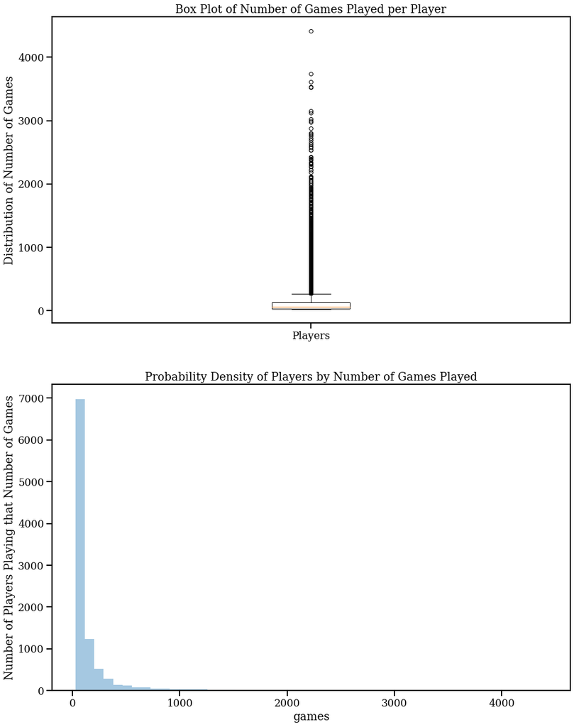

```python
fig, ax = plt.subplots(2, 1, figsize=(15, 20))
ax[0].boxplot(df2['games'].dropna())
ax[0].set_title('Box Plot of Number of Games Played per Player')
ax[0].set_xticklabels(['Players'])
ax[0].set_ylabel('Distribution of Number of Games')
ax[1] = sns.distplot(df2['games'].dropna(), kde=False)
ax[1].set_title('Probability Density of Players by Number of Games Played')
ax[1].set_ylabel('Number of Players Playing that Number of Games')
plt.show()
```

#### ANALYSIS

The distribution of games played shows some sort of a power law, where there are a great number of players who only played few games, but a few who played many games.

## Section 4. Story

Based on what we can glean from the chessgames website, what are the trends in chess over the years?

### Number of Games

We noticed earlier that although the number of chess tournament games had generally been increasing over time, there were periods which saw declines. Let's plot the number of games per year, from 1843 to 2019.

The number of games (y-axis) will be represented as a logarithmic scale to mitigate the effect of the balloon in the number of games recently.

*Here we plot the Number of Tournament Games Played per Year vs. the Number of Tournament Games Played for that year.*

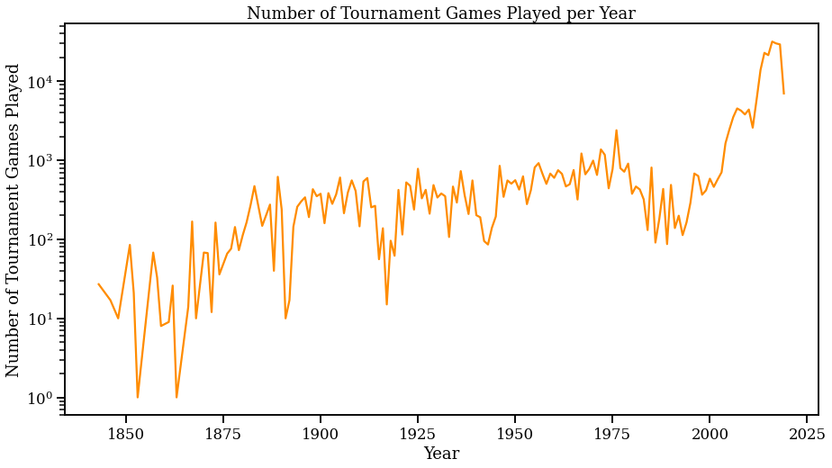

```python
df1_games = df1.groupby('year')['game'].count()

fig, ax = plt.subplots(1, 1, figsize=(15, 8))
ax = df1_games.plot(color='darkorange')
ax.set_xlabel('Year')
ax.set_ylabel('Number of Tournament Games Played')
ax.set_title('Number of Tournament Games Played per Year')
ax.set_yscale('log')
plt.show()
```

#### ANALYSIS

There is a generally increasing trend in the number of tournament games per year, but we notice several dips in the 1890s, from 1915-1919, from 1941-1945, and in the 1980s. The dip in 2019 is because the year is not finished yet.

We cannot explain the dips in the 1890s and 1980s, but it is likely that the dips in 1915-1919 and 1941-1945 are connected to World War I and II, respectively.

It is good to see that there has been an exponential increase in the number of chess tournaments starting approximately in the 1990s. This increase is so pronounced that we had to plot the above chart on a semilogarithmic scale. On the other hand, this may be because chess games and tournaments are better documented in recent times due to improved technological capability.

### Winning Percentage by Side

In the tournament DataFrame, `df_tourn_games`, there is a column named `result`, containing the outcome of each game.

The possible outcomes are as follows:

- 1-0 : White Victory
- 0-1 : Black Victory
- ½-½ : Draw

*This cell will show the number of games won by White, Black, or a Draw, and the winning percentage of each.*

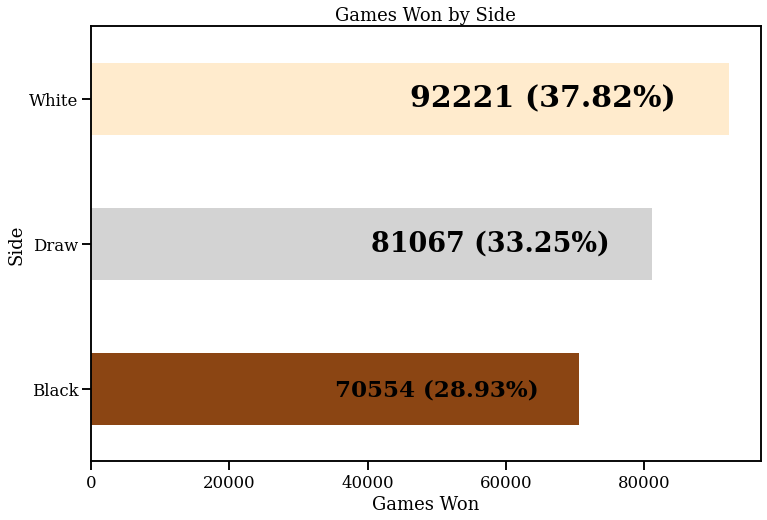

```python
result_dict = {'1-0': 'White', '0-1': 'Black', '½-½': 'Draw',
               'total': 'total'}
color_dict = {'White': 'blanchedalmond',
              'Draw': 'lightgray', 'Black': 'saddlebrown'}
df1_bw = df1.groupby('result')['game'].count().sort_values(ascending=True)
df1_bw.index = [result_dict[result] for result in df1_bw.index]
fig, ax = plt.subplots(1, 1, figsize=(12, 8))
ax = df1_bw.plot.barh(color=[color_dict[color] for color in df1_bw.index])
ax.set_title('Games Won by Side')
ax.set_xlabel('Games Won')
ax.set_ylabel('Side')
for i, v in enumerate(df1_bw.values):
    ax.text(v/2, i-0.05, (str(v)+' ({:.02f}%)'.format(
        100*v/sum(df1_bw.values))), color='k', fontweight='bold',
            fontsize=int(v/3000))
plt.show()
```

#### ANALYSIS

White has an undeniable advantage over Black.

Despite being ahead by only half a move, White is able to take offense immediately, and thus Black is often forced into defense very early on.

### Number of Moves

How has the number of moves in chess tournament games changed over the years?

*The following cell groups the number of moves by year and averages them, to get the mean number of moves for all games in a year.*

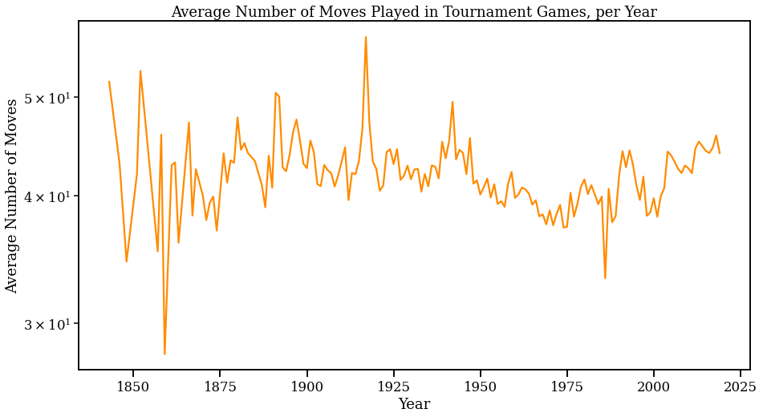

```python
df1_moves = df1.groupby('year')['moves'].mean()

fig, ax = plt.subplots(1, 1, figsize=(15, 8))
ax = df1_moves.plot(color='darkorange')
ax.set_xlabel('Year')
ax.set_ylabel('Average Number of Moves')
ax.set_title('Average Number of Moves Played in Tournament Games, per Year')
ax.set_yscale('log')
plt.show()
```

#### ANALYSIS

Over time, there does not seem to be a general trend in the number of moves. It is relatively stable at around 40-45.

It may be noticed that the number of moves occasionally fluctuates abnormally high or low. The reason for this is likely because these spikes tend to coincide with the slumps (dips) in the number of games per year. In these cases, the mean becomes more sensitive to outliers. Thus, nothing can be concluded.

Nevertheless, it is interesting to note that some of the highest spikes coincide with the two World Wars (1917 and 1943).

### Opening Moveset

"Opening", or "Opening moves", is a term used to refer to the first few moves in a chess game. The opening chosen will depend much on the personal skill, style, and preference of the player, and its success will also depend on how well the opponent defends against it. Through the years, some openings have been developed, tried, tested, and extensively studied. The following chart shows the Top 10 openings from 1843 to 2019.

*This cell re-plots the Top 10 Chess Opening Moveset.*

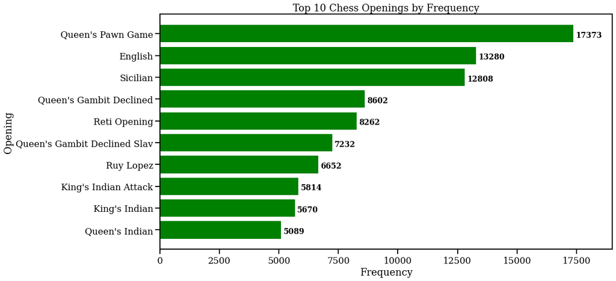

```python
fig, ax = plt.subplots(1, 1, figsize=(15, 8))
openings = sorter(df1_openings.index, df1_openings)
widths = openings[1][-10:]
ax.barh(openings[0][-10:], widths, color='green')
ax.set_xlim(0, 19000)
ax.set_title('Top 10 Chess Openings by Frequency')
ax.set_xlabel('Frequency')
ax.set_ylabel('Opening')
for i, v in enumerate(widths):
    ax.text(v+100, i-0.17, str(v), color='k', fontweight='bold', fontsize=14)
```

#### ANALYSIS

Some Chess Openings are frequently used, likely because of their effectiveness or simply because of popularity. Using a less-popular opening might be less effective, but also might catch an opponent by surprise.

### Chess Openings, for White

Different Chess openings can produce different results depending on which side you are on (Black or White). One of the best ways to measure the effectiveness of different openings is the frequency of use, but measuring the winning percentages can be useful as well.

For White, which Chess openings produce the highest winning percentages?

*The following code plots the Top 10 Chess Openings for White with winning percentage as the basis.*

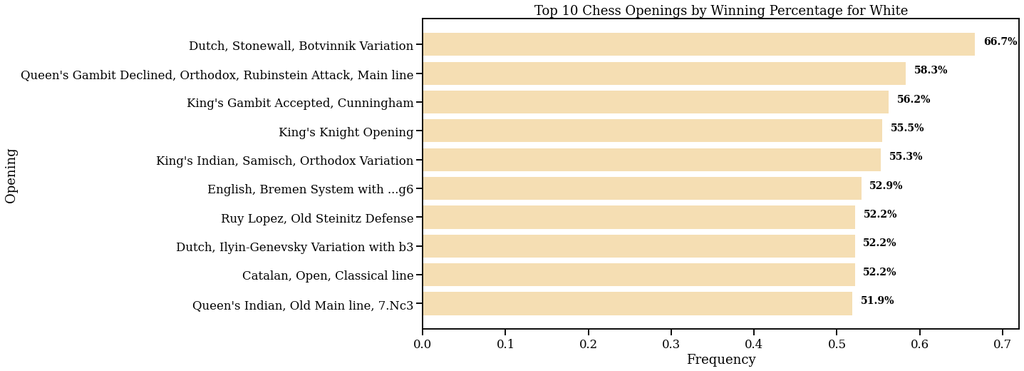

```python
# Filtering only those openings with at least 10 games played:
df1_openings_wins_10 = df1_openings_wins[df1_openings_wins['total'] > 10]

try:
    df1_openings_wins_10.columns = \
        [result_dict[x] for x in df1_openings_wins_10.columns]
except:
    pass
fig, ax = plt.subplots(1, 1, figsize=(15, 8))
openings = sorter(df1_openings_wins_10.index, df1_openings_wins_10['White'])
widths = openings[1][-10:]
ax.barh(openings[0][-10:], widths, color='wheat')
ax.set_xlim(0, 0.72)
ax.set_title('Top 10 Chess Openings by Winning Percentage for White')
ax.set_xlabel('Frequency')
ax.set_ylabel('Opening')
for i, v in enumerate(widths):
    ax.text(v+0.01, i, '{}%'.format(round(v*100, 1)),
            color='k', fontweight='bold', fontsize=14)
```

#### ANALYSIS

Here we see the Chess openings with the highest winning percentages for White. Players on the White side of the board might want to consider these strategies if they want to win more often.

### Chess Openings, for Black

For Black, which Chess openings produce the highest winning percentages?

*The following code plots the Top 10 Chess Openings for Black with winning percentage as the basis.*

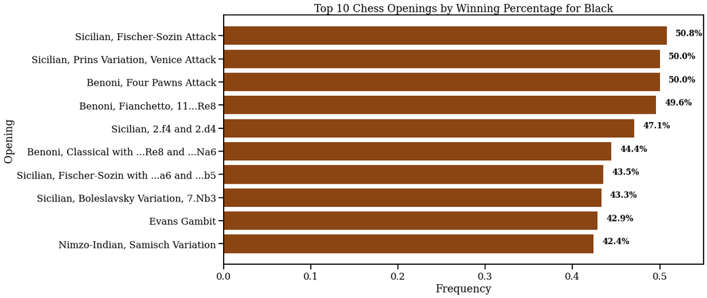

```python
fig, ax = plt.subplots(1, 1, figsize=(15, 8))
openings = sorter(df1_openings_wins_10.index, df1_openings_wins_10['Black'])
widths = openings[1][-10:]
ax.barh(openings[0][-10:], widths, color='saddlebrown')
ax.set_xlim(0, 0.55)
ax.set_title('Top 10 Chess Openings by Winning Percentage for Black')
ax.set_xlabel('Frequency')
ax.set_ylabel('Opening')
for i, v in enumerate(widths):
    ax.text(v+0.01, i, '{}%'.format(round(v*100, 1)),
            color='k', fontweight='bold', fontsize=14)
```

#### ANALYSIS

Here we see the Chess openings with the highest winning percentages for Black. They are mostly Sicilian and Benoni openings. Thus, players on the Black side of the board might want to consider Sicilian and Benoni strategies if they want to win more often.

### Chess Notation

According to 'https://www.dummies.com/games/chess/understanding-chess-notation/':

> Many kinds of chess notation exist, from forsythe (a notation that computers understand) to different notations for various languages. One kind of notation, however, is universally understood: *algebraic*, which uses a single letter and number to name each square and a letter for each chess piece. This notation system replaced the older English descriptive notation — which used an abbreviated form of a verbal description of the moves — because chess is for all people, not just English-speaking people.

The numbering and lettering of the chess board is oriented to the white player’s position and looks like this:

[figure not shown]

White at bottom, Black at top.

The 'Chess Opening Explorer' page on the chessgames site allows users to explore different possible starting combinations of moves. However, exploring deep (more number of moves) requires their premium subscription, and thus we will only analyze the very first move of White.

*The following code creates several DataFrames that will allow us to plot the frequency of opening squares into a heatmap.*

```python
df_exp_trunc = df_explorer.copy()
df_exp_trunc['move'] = df_explorer['move'].apply(lambda x: x[-2:])
df_exp_trunc['col'] = df_exp_trunc['move'].apply(lambda x: x[0])
df_exp_trunc['row'] = df_exp_trunc['move'].apply(
    lambda x: x[1]).astype('int64')

df_board = pd.DataFrame(columns=list(
    string.ascii_lowercase[:8]), index=range(1, 9)).fillna(0)
df_whites = pd.DataFrame(columns=list(
    string.ascii_lowercase[:8]), index=range(1, 9)).fillna(0)
df_blacks = pd.DataFrame(columns=list(
    string.ascii_lowercase[:8]), index=range(1, 9)).fillna(0)

for idx in df_exp_trunc.index:
    row = df_exp_trunc['row'][idx]
    col = df_exp_trunc['col'][idx]
    df_board.loc[row, col] += df_exp_trunc['games'][idx]
    df_whites.loc[row, col] += (df_exp_trunc['white']
                                [idx]*df_exp_trunc['games'][idx])
    df_blacks.loc[row, col] += (df_exp_trunc['black']
                                [idx]*df_exp_trunc['games'][idx])

df_board.fillna(0, inplace=True)
df_whites = (df_whites / df_board).fillna(0)
df_blacks = (df_blacks / df_board).fillna(0)
df_blacks.fillna(0, inplace=True)
df_board = df_board.astype('int64')
```

### What Squares Does White Play?

White has a total of 16 squares that it may play at the beginning; eight pawns may move either one or two steps forward, or the knights have two possible moves each, making for 20 possible starting moves. Which squares are most often played by White?

*White can play all 16 squares but tends to play only a few squares very frequently, thus making for an uninformative heatmap. To attempt to remedy this, let us plot frequency on a logarithmic scale instead.*

*This code plots the frequency of openings squares used by White on a heatmap. The logarithms of the frequencies have been taken.*

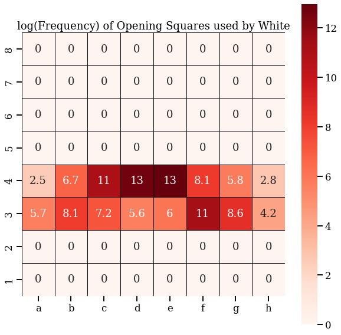

```python
fig, ax = plt.subplots(1, 1, figsize=(10, 10))
ax = sns.heatmap(
    np.log(df_board.sort_index(ascending=False)).replace(-np.inf, np.nan)
    .fillna(0), cmap='Reds', square=True, annot=True, annot_kws={"size": 18},
    linewidths=1, linecolor='k')
ax.set_title('log(Frequency) of Opening Squares used by White')

plt.show()
```

#### ANALYSIS

White almost always plays `e4` and `d4`; the middle two pawns moving two squares forward. These moves allow early mobility for the queen and/or the bishops.

### How Often Does White Win, Playing These Squares?

When playing these squares, how often does White win? Let us plot the winning percentage of White for each of the 16 squares.

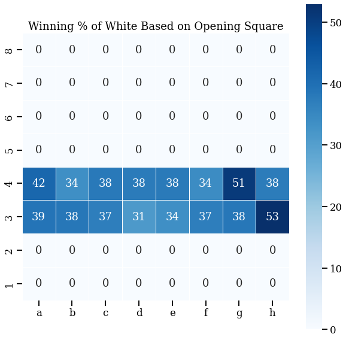

```python
fig, ax = plt.subplots(1, 1, figsize=(10, 10))
ax = sns.heatmap(df_whites.sort_index(ascending=False), linewidths=1,
                 cmap='Blues', square=True, annot=True,
                 annot_kws={"size": 18})
ax.set_title('Winning % of White Based on Opening Square')
plt.show()
```

#### ANALYSIS

White wins most often when playing `h3` and `g4`. Interestingly, these squares are quite rarely played by White as their first move. This information can be important to players playing White as they will know which squares might grant them greater probabilities of winning.

### How Often Does Black Win, Given White Played These Squares?

Black is naturally at a disadvantage, being second to move. They are put into a defensive position from the beginning, and thus their strategy will be highly dependent on White. Given that, what is Black's winning percentage given White's first move?

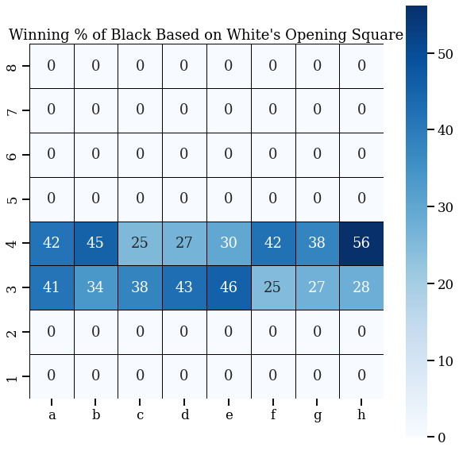

```python
fig, ax = plt.subplots(1, 1, figsize=(10, 10))
ax = sns.heatmap(df_blacks.sort_index(ascending=False), linewidths=1,
                 linecolor='k', cmap='Blues', square=True, annot=True,
                 annot_kws={"size": 18})
ax.set_title("Winning % of Black Based on White's Opening Square")
plt.show()
```

#### ANALYSIS

This graph can help White know which squares not to play if they want to have a higher probability of winning. While it seems the numbers are higher on this heatmap than on the above, it must be remembered that White plays `d4` and `e4` at an exponentially higher rate than Black's high percentage squares in this heatmap; thus, White's winning percentage remains higher.

Black has the highest percentage of winning given White plays `h4`. This information is significantly less useful to Black than it is to White.

### Player Ratings

According to Wikipedia,

> A player's Elo rating is represented by a number which increases or decreases depending on the outcome of games between rated players. After every game, the winning player takes points from the losing one. The difference between the ratings of the winner and loser determines the total number of points gained or lost after a game. In a series of games between a high-rated player and a low-rated player, the high-rated player is expected to score more wins. If the high-rated player wins, then only a few rating points will be taken from the low-rated player. However, if the lower-rated player scores an upset win, many rating points will be transferred. The lower-rated player will also gain a few points from the higher rated player in the event of a draw. This means that this rating system is self-correcting.

Several organizations keep their own Elo ratings of chess players, including the Fédération Internationale des Échecs or World Chess Federation (**FIDE**).

In general, how do players' FIDE ratings fare as they play more and more games?

*Let's try plotting the highest FIDE rating achieved against the total number of games played. Each point represents one player.*

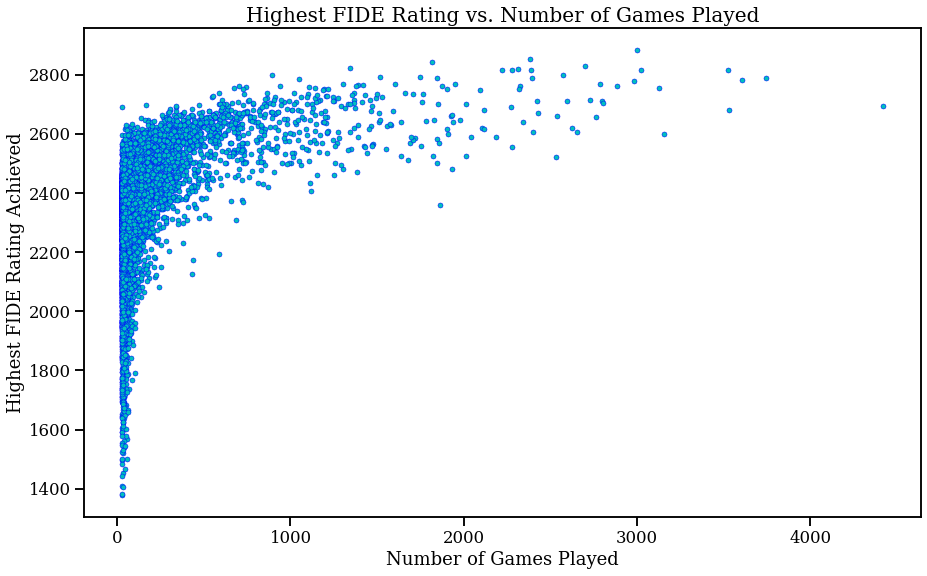

```python
fig, ax = plt.subplots(1, 1, figsize=(15, 9))
ax.plot(df2['games'], df2['fide'], 'c.', ms=10,
        mew=0.5, mec='Blue', label='Data')
ax.set_title("Highest FIDE Rating vs. Number of Games Played", fontsize=20)
ax.set_xlabel('Number of Games Played')
ax.set_ylabel('Highest FIDE Rating Achieved')
plt.show()
```

#### ANALYSIS

Looks like either an exponential relationship or a power law! This makes sense because players with lower ratings should be able to climb faster, because they are awarded more points for winning a match. As the above-mentioned article continues,

> Players whose ratings are too low should, in the long run, do better than the rating system predicts and thus gain rating points until the ratings reflect their true playing strength.

Thus, if one simply want to attain a respectable FIDE rating, then they need not play very many games, but if one wants to achieve a very high FIDE rating, then one should play a disproportionate number of games.

*Re-plotting the same as above, but using a logarithmic scale.*

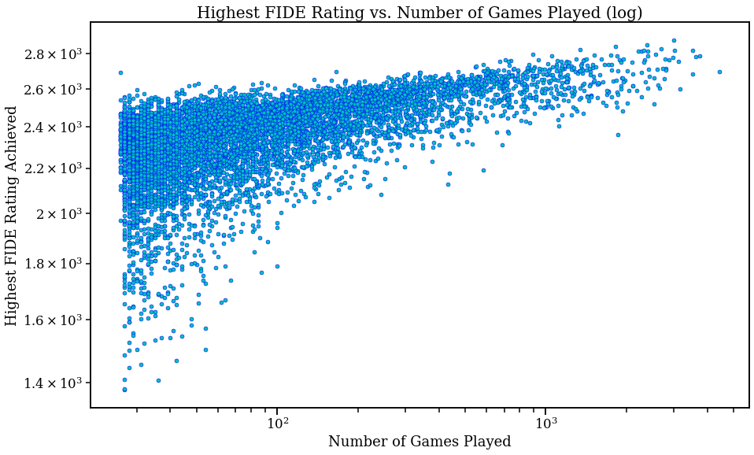

```python
fig, ax = plt.subplots(1, 1, figsize=(15, 9))
ax.plot(df2['games'], df2['fide'], 'c.', ms=10,
        mew=0.5, mec='Blue', label='Data')
ax.set_xscale('log')
ax.set_yscale('log')
ax.set_title(
    "Highest FIDE Rating vs. Number of Games Played (log)", fontsize=20)
ax.set_xlabel('Number of Games Played')
ax.set_ylabel('Highest FIDE Rating Achieved')
plt.show()
```

The trend is starting to become apparent. To finish this analysis, let's fit the points to a power law.

*The following code defines a power law function, and fits the data points to the function using lmfit. The data points are plotted (scatter), the initial guess is the black dashed line, and the final 'best' fit is plotted as a solid red line.*

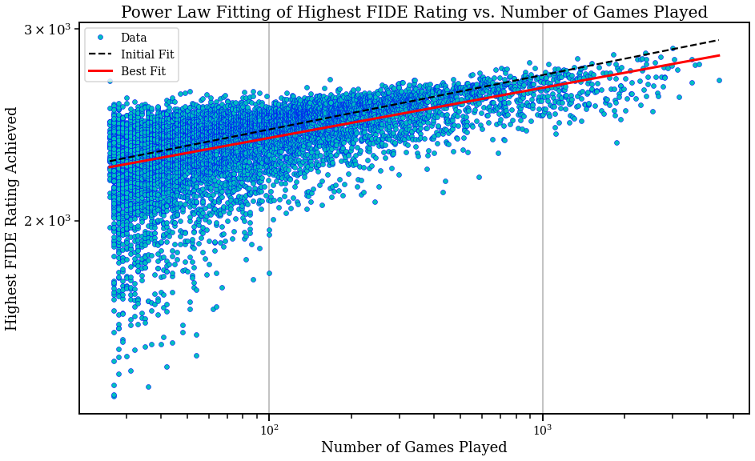

```python
def power(x, A, alpha):
    return A * x ** (-alpha)


df2_games_fide = df2[['games', 'fide']].copy().dropna()

x = np.array(df2_games_fide['games'])
y = np.array(df2_games_fide['fide'])
y, x = sorter(y, x)

power_model = Model(power)
results_power = power_model.fit(y, x=x, A=1927, alpha=-0.05)
# print(results_power.fit_report())

plt.figure(figsize=(15, 9))

plt.loglog(x, y, 'co', ms=6, mew=0.5, mec='Blue', label="Data")
plt.loglog(x, results_power.init_fit, 'k--', label="Initial Fit")
plt.loglog(x, results_power.best_fit, 'r-', lw=3, label="Best Fit")
plt.xlabel('Number of Games Played')
plt.ylabel('Highest FIDE Rating Achieved')
plt.title(
    "Power Law Fitting of Highest FIDE Rating vs. Number of Games Played",
    fontsize=20)
plt.legend(loc='upper left', fontsize=14)
plt.grid()
plt.tick_params(labelsize=14)

plt.show()
```

#### ANALYSIS

Playing more and more games sees diminishing marginal returns on the FIDE rating.

However, it is notable to observe that the lower right portion of the graph is blank, meaning that although people who played a low number of games could get high FIDE ratings straight away, no one who played a high number of games remained with a low FIDE rating.

**Thus, the best way to increase FIDE rating is still to play more games.**

### Chessforums

What do the forum creators on the chessforums talk about? By making a word cloud from the posts, we may be able to identify the hot topics in chess.

*The following cells join all forum posts (not comments) into one long string, import WordCloud module from its library and construct a wordcloud from the chessforum posts.*

```python
df_texts
no_stops_text = ' '.join(list(df_texts['text']))
```

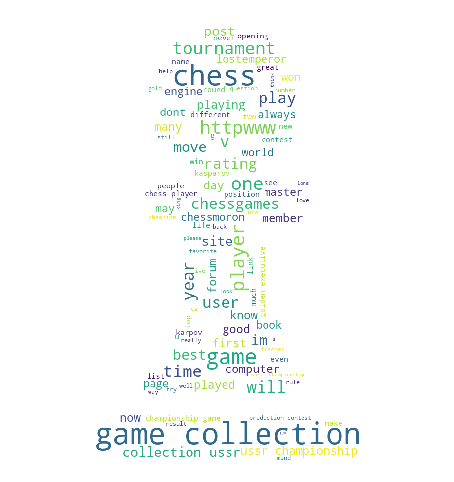

```python
def create_word_cloud(string):
    mask = np.array(Image.open('figures/pawn.png'))
    cloud = WordCloud(background_color="white", max_words=100,
                      mask=mask, stopwords=set(STOPWORDS))
    cloud.generate(string)
    cloud.to_file('figures/wordcloud.png')


create_word_cloud(no_stops_text)

PImage(filename='figures/wordcloud.png')
```

#### ANALYSIS

Many different terms are in the word cloud, including but not limited to:

1. Contest-related terms such as 'game', 'tournament', 'chess', 'player', 'master', 'championship', 'move', etc.
2. Famous players such as Karpov, Kasparov, Fischer, etc.
3. 'USSR' appears a few times, showing the significant contribution of the Soviet Union to Chess
4. Interestingly, the term 'chessmoron' appears, possibly indicating some conflicts between chessforum members.

## Section 5. Conclusion and Closing

With more tournaments being held, there are more opportunities for enthusiasts to display their prowess in the game of chess. Further, it is only through playing (and winning) in more chess tournaments that a player will improve his or her FIDE-rating.

From the analysis of the first/opening moves, enthusiasts will have the idea on how to start their games. However, this is just the first of the so many other moves to complete the game. Therefore, players should not just stop at learning the best first moves, but should also learn on what the succeeding moves should be, particularly in response to the opponents’ move. Nevertheless, having a good first move provides a one-move advantage already and a good confidence level to start the game.

Lastly, there are discussion forums available in the internet where enthusiasts can follow discussions or ask questions regarding the game of chess. These forums have members from around the globe who have various levels of expertise. There is a good chance that somebody might have been in the same situation that you are and that he or she may have already dealt with the situation or may have the right next steps to move forward to complete and to win the game.

Enjoy the game!